[figure not shown]

# Financial News Headline Sentiment Analysis

A Project by Tim Körppen (Bachelor Wirtschaftsinformatik) and Hannes Weichelt (Bachelor Informatik/CS) for the Course *"Intelligent Data Analysis & Machine Learning"* at University of Potsdam.

## Notebook Structure

1. **Exploratory data analysis**
2. **Preprocessing**
   1. Removing class distribution biases
   2. Removing Duplicates
   3. Removing disruptive words
   4. Removing Punctuation
   5. Tokenizing
   6. Removing Stopwords
   7. Lemmatizing
   8. Feature Creation
3. **Model selection**
   1. Preparing Nested Cross Validation
   2. Support Vector machine
   3. Random Forest
   4. Model comparison and Evaluation
      1. Top Features
      2. Confusuion Matrix and F1-Score
      3. ROC Curves and AUC
      4. Selecting the better model
      5. Testing our model on some real world data
4. **Conclusion and outlook**
   1. Outlookon possible future model imporvements

## Project origin and short Summary

We decided to focus our project on the topic of financial news headline sentiment analysis. For that we used a fitting dataset from kaggle (https://www.kaggle.com/ankurzing/sentiment-analysis-for-financial-news/notebooks?sortBy=voteCount&group=everyone&pageSize=20&datasetId=622510)

The Dataset consists of roughly 5000 financial news headlines and provides a sentiment classification as a label (divided into "positive", "neutral", "negative"). Our goal with this project ist to train a machine learning classifier to analyse and recognise the sentiment of these news headlines.

Our motivation for this kind of project is the ever growing relevance NLP and Word-Tokenizing in the world of digital voice assistants and Automated Chatbots. A machine learning Model that can recognise the sentiment of the current news trends can also be very useful in the finance world for example if you are deciding about your future investments.

## Import important Packages

```python
import nltk
# nltk.download()
```

```python
import pandas as pd
import itertools
import matplotlib.pyplot as plt
import numpy as np
import re
```

```python
color_map = 'Pastel1'
np.random.seed(42)
```

## Helper functions for developement purposes

Funcion to search for specific words in the headline data :

```python
def filter_df(df, keyword):
    mask = []
    for index, row in df.iterrows():
        if keyword in row['text'].lower().split():
            mask.append(index)

    return df.iloc[mask,:]
```

# 1. Exploratory data analysis

```python
original_data = pd.read_csv("all-data.csv", encoding = "ISO-8859-1", header=None, names=["res", "text"])
news_headline_data = original_data.copy(deep=True)
news_headline_data
```

|  | res | text |
| --- | --- | --- |
| 0 | neutral | According to Gran , the company has no plans t... |
| 1 | neutral | Technopolis plans to develop in stages an area... |
| 2 | negative | The international electronic industry company ... |
| 3 | positive | With the new production plant the company woul... |
| 4 | positive | According to the company 's updated strategy f... |
| ... | ... | ... |
| 4841 | negative | LONDON MarketWatch -- Share prices ended lower... |
| 4842 | neutral | Rinkuskiai 's beer sales fell by 6.5 per cent ... |
| 4843 | negative | Operating profit fell to EUR 35.4 mn from EUR ... |
| 4844 | negative | Net sales of the Paper segment decreased to EU... |
| 4845 | negative | Sales in Finland decreased by 10.5 % in Januar... |

4846 rows × 2 columns

### Give an overview over the News Headline Dataset

```python
news_headline_data.info()
news_headline_data.describe()
```

```
<class 'pandas.core.frame.DataFrame'>
RangeIndex: 4846 entries, 0 to 4845
Data columns (total 2 columns):
 #   Column  Non-Null Count  Dtype
---  ------  --------------  -----
 0   res     4846 non-null   object
 1   text    4846 non-null   object
dtypes: object(2)
memory usage: 75.8+ KB
```

|  | res | text |
| --- | --- | --- |
| count | 4846 | 4846 |
| unique | 3 | 4838 |
| top | neutral | The company serves customers in various indust... |
| freq | 2879 | 2 |

### Visualize the Distribution of the Sentiment Labels

```
neutral     2879
positive    1363
negative     604
Name: res, dtype: int64
```

[figure not shown]

```python
val_counts = (news_headline_data['res'].value_counts())
print(val_counts)
val_counts.plot(kind='bar', title='Distribution of News Headlines in percent', cmap=color_map)
```

### Distrubution of Headline Lenght

```
mean : 128.1320676846884
min : 9
max : 315
```

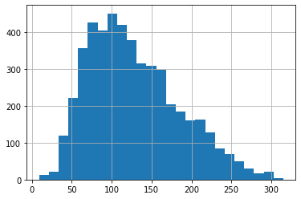

```python
print(f"mean : {news_headline_data['text'].str.len().mean()}")
print(f"min : {news_headline_data['text'].str.len().min()}")
print(f"max : {news_headline_data['text'].str.len().max()}")

news_headline_data['text'].str.len().sort_values().hist(bins=25)
```

### The shortest Headlines

```python
news_headline_data[news_headline_data['text'].str.len() <= 23]
```

|  | res | text |
| --- | --- | --- |
| 1023 | neutral | All are welcome . |
| 1116 | neutral | Welcome ! |
| 2356 | neutral | `` We could be there . |
| 2399 | neutral | All rights reserved . |
| 2518 | neutral | Net investment income |
| 2569 | neutral | Status : Agreed |
| 2983 | neutral | It 's not . |
| 3040 | neutral | ND = Not disclosed . |
| 3061 | neutral | NWC ANALYSIS : |
| 3099 | neutral | R&D Loan ) . |
| 3450 | neutral | What we think ? |
| 3464 | neutral | You 're not alone . |
| 3486 | neutral | `` This could be us . |
| 3720 | neutral | pct lower at 4,442.10 . |

### The longest Headlines

```python
long_headlines = news_headline_data[news_headline_data['text'].str.len() >= 280]['text']
for i in range(3):
    print(long_headlines.iloc[i]+'\n')
```

```
At the request of Finnish media company Alma Media 's newspapers , research manager Jari Kaivo-oja at the Finland Futures Research Centre at the Turku School of Economics has drawn up a future scenario for Finland 's national economy by using a model developed by the University of Denver .

`` The new agreement is a continuation to theagreement signed earlier this year with the Lemminkainen Group , whereby Cramo acquired the entire construction machine fleet ofLemminkainen Talo Oy Ita - ja Pohjois Suomo , and signed asimilar agreement , '' said Tatu Hauhio , managing director ofCramo F…

The Finnish supplier of BSS-OSS and VAS for telecom operators , Tecnotree , has received expansion orders worth a total US$ 7.3 mn for its convergent charging and next generation messaging solutions in Latin America , the company announced without specifying which operators had placed the orders .
```

### Word Frequency in Headlines

```
dictionary_size : 12939
```

|  | Word | Frequency |
| --- | --- | --- |
| 0 | . | 4846 |
| 1 | the | 4712 |
| 2 | , | 4663 |
| 3 | of | 3202 |
| 4 | in | 2752 |
| 5 | and | 2585 |
| 6 | to | 2496 |
| 7 | a | 1631 |
| 8 | The | 1354 |
| 9 | for | 1130 |
| 10 | 's | 996 |
| 11 | is | 925 |
| 12 | EUR | 918 |
| 13 | will | 849 |
| 14 | company | 801 |
| 15 | from | 766 |
| 16 | on | 666 |
| 17 | its | 636 |
| 18 | has | 578 |
| 19 | by | 550 |
| 20 | with | 548 |
| 21 | said | 545 |
| 22 | be | 542 |
| 23 | ) | 527 |
| 24 | ( | 525 |
| 25 | mn | 515 |
| 26 | Finnish | 512 |
| 27 | as | 479 |
| 28 | `` | 471 |
| 29 | % | 445 |

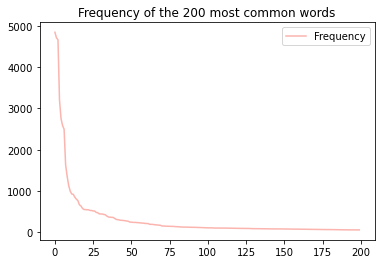

```python
tokenized_sentences = [nltk.word_tokenize(text) for text in news_headline_data['text']]
word_freq = nltk.FreqDist(itertools.chain(*tokenized_sentences))

#word_freq.plot(200)
df_most_common_words = pd.DataFrame(word_freq.most_common(200), columns = ['Word', 'Frequency'])
df_most_common_words.plot(cmap=color_map, title='Frequency of the 200 most common words')

print(f'dictionary_size : {len(word_freq)}')
df_most_common_words.iloc[:30,:]
```

# 2. Preprocessing

1. **Preprocessing**
   1. Removing class distribution biases
   2. Removing Duplicates
   3. Removing disruptive words
   4. Removing Punctuation
   5. Tokenizing
   6. Removing Stopwords
   7. Lemmatizing
   8. Feature Creation

```python
news_headline_data
```

|  | res | text |
| --- | --- | --- |
| 0 | neutral | According to Gran , the company has no plans t... |
| 1 | neutral | Technopolis plans to develop in stages an area... |
| 2 | negative | The international electronic industry company ... |
| 3 | positive | With the new production plant the company woul... |
| 4 | positive | According to the company 's updated strategy f... |
| ... | ... | ... |
| 4841 | negative | LONDON MarketWatch -- Share prices ended lower... |
| 4842 | neutral | Rinkuskiai 's beer sales fell by 6.5 per cent ... |
| 4843 | negative | Operating profit fell to EUR 35.4 mn from EUR ... |
| 4844 | negative | Net sales of the Paper segment decreased to EU... |
| 4845 | negative | Sales in Finland decreased by 10.5 % in Januar... |

4846 rows × 2 columns

## Removing class distribution Biases

```python
vc = original_data['res'].value_counts()
vc
```

```
neutral     2879
positive    1363
negative     604
Name: res, dtype: int64
```

```python
drop_indices = np.random.choice(original_data[original_data["res"]=="neutral"].index, vc[0]-vc[1], replace=False)
news_headline_data = original_data.drop(drop_indices)
news_headline_data
```

|  | res | text |
| --- | --- | --- |
| 1 | neutral | Technopolis plans to develop in stages an area... |
| 2 | negative | The international electronic industry company ... |
| 3 | positive | With the new production plant the company woul... |
| 4 | positive | According to the company 's updated strategy f... |
| 5 | positive | FINANCING OF ASPOCOMP 'S GROWTH Aspocomp is ag... |
| ... | ... | ... |
| 4840 | negative | HELSINKI Thomson Financial - Shares in Cargote... |
| 4841 | negative | LONDON MarketWatch -- Share prices ended lower... |
| 4843 | negative | Operating profit fell to EUR 35.4 mn from EUR ... |
| 4844 | negative | Net sales of the Paper segment decreased to EU... |
| 4845 | negative | Sales in Finland decreased by 10.5 % in Januar... |

3330 rows × 2 columns

## Remove Duplicates

```python
news_headline_data.describe()
```

|  | res | text |
| --- | --- | --- |
| count | 3330 | 3330 |
| unique | 3 | 3326 |
| top | positive | The Group 's business is balanced by its broad... |
| freq | 1363 | 2 |

```python
news_headline_data = news_headline_data.loc[news_headline_data["text"].drop_duplicates().index].reset_index(drop=True)
news_headline_data.describe()
```

|  | res | text |
| --- | --- | --- |
| count | 3326 | 3326 |
| unique | 3 | 3326 |
| top | positive | The order also includes start-up and commissio... |
| freq | 1362 | 1 |

## Removing disruptive Words

While testing our models we could observe that our dataset had some common words like **"euro"** , **"mio"** or **"$"** that would get very high feature importances but couldn't contribute much information for the sentiment of the news headline. We decided to drop these common disruptive words from our dataset, which proved successful and resulted in a better performing model.

```python
def remove_synonyms(string, synonym_list):
    string_split = np.array(string.lower().split())
    for synonym in synonym_list:
        if synonym in string_split:
            mask = string_split == synonym
            string_split[mask] = ''

    return " ".join(string_split)
```

We also decided to drop all numeric values of our data, because our small dataset size wouldn't allow for the estimator to gain usefull information out of them.

```python
def remove_numbers(string):
    tmp = re.sub(r'[.,]', '', string)
    tmp = re.sub(r'\d*[0-9]', '', tmp)
    return tmp
```

## Step 1 : Word-Removing

applying the text- and number-removing functions to the headlines

```python
news_headline_data['text_replaced'] = news_headline_data['text'].apply(lambda x: remove_numbers(x))
news_headline_data['text_replaced'] = news_headline_data['text_replaced'].apply(lambda x: remove_synonyms(x, ["mln", "m.","m","mn", "mio", "mio.","mln."]))
news_headline_data['text_replaced'] = news_headline_data['text_replaced'].apply(lambda x: remove_synonyms(x, ['bln', 'bln.', 'bn']))
news_headline_data['text_replaced'] = news_headline_data['text_replaced'].apply(lambda x: remove_synonyms(x, ["€", "eur", "eur.", "euro"]))
news_headline_data['text_replaced'] = news_headline_data['text_replaced'].apply(lambda x: remove_synonyms(x, ["$", "dollar"]))
news_headline_data['text_replaced'] = news_headline_data['text_replaced'].apply(lambda x: remove_synonyms(x, ["%"]))
news_headline_data.head(1)
```

|  | res | text | text_replaced |
| --- | --- | --- | --- |
| 0 | neutral | Technopolis plans to develop in stages an area... | technopolis plans to develop in stages an area... |

## Setp 2 : Remove Punctuation

```python
import string

def remove_punctuation(text):
    # remove all chars that are in string.punctuation
    res = ''.join([char for char in text if char not in string.punctuation])
    return res
```

```python
news_headline_data['text_punctuation_removed'] = news_headline_data['text_replaced'].apply(lambda x: remove_punctuation(x))
news_headline_data.head(1)
```

|  | res | text | text_replaced | text_punctuation_removed |
| --- | --- | --- | --- | --- |
| 0 | neutral | Technopolis plans to develop in stages an area... | technopolis plans to develop in stages an area... | technopolis plans to develop in stages an area... |

## Step 3 : Tokenizing

```python
news_headline_data['text_tokenized'] = news_headline_data['text_punctuation_removed'].apply(lambda x: nltk.word_tokenize(x))
news_headline_data.head(1)
```

|  | res | text | text_replaced | text_punctuation_removed | text_tokenized |
| --- | --- | --- | --- | --- | --- |
| 0 | neutral | Technopolis plans to develop in stages an area... | technopolis plans to develop in stages an area... | technopolis plans to develop in stages an area... | [technopolis, plans, to, develop, in, stages, ... |

## Step 4 : Remove Stopwords

```python
stopwords = nltk.corpus.stopwords.words('english') # contains all english stopwords

def remove_stopwords(tokenized_text):
    res = [word for word in tokenized_text if word not in stopwords]
    return res
```

```python
news_headline_data['text_stopwords_removed'] = news_headline_data['text_tokenized'].apply(lambda x: remove_stopwords(x))
news_headline_data.head(1)
```

|  | res | text | text_replaced | text_punctuation_removed | text_tokenized | text_stopwords_removed |
| --- | --- | --- | --- | --- | --- | --- |
| 0 | neutral | Technopolis plans to develop in stages an area... | technopolis plans to develop in stages an area... | technopolis plans to develop in stages an area... | [technopolis, plans, to, develop, in, stages, ... | [technopolis, plans, develop, stages, area, le... |

## Step 5 : Lemmatizing

We are using lemmatizing and not stemming here, because lemmatizing is more accurate that stemming. That is because it uses an informed analysis of the word with its context in mind rather than just chopping off the end of the word like stemming.

```python
lemmatizer = nltk.WordNetLemmatizer()

def lemmatizing(tokenized_text):
    res = [lemmatizer.lemmatize(word) for word in tokenized_text]
    return res
```

```python
news_headline_data['text_lemmatized'] = news_headline_data['text_stopwords_removed'].apply(lambda x: lemmatizing(x))
news_headline_data.head(1)
```

|  | res | text | text_replaced | text_punctuation_removed | text_tokenized | text_stopwords_removed | text_lemmatized |
| --- | --- | --- | --- | --- | --- | --- | --- |
| 0 | neutral | Technopolis plans to develop in stages an area... | technopolis plans to develop in stages an area... | technopolis plans to develop in stages an area... | [technopolis, plans, to, develop, in, stages, ... | [technopolis, plans, develop, stages, area, le... | [technopolis, plan, develop, stage, area, le, ... |

## Joining the Lemmatized Word-Array to a final String

```python
news_headline_data['text_final'] = news_headline_data['text_lemmatized'].apply(lambda x : " ".join(x))
news_headline_data.head(1)
```

|  | res | text | text_replaced | text_punctuation_removed | text_tokenized | text_stopwords_removed | text_lemmatized | text_final |
| --- | --- | --- | --- | --- | --- | --- | --- | --- |
| 0 | neutral | Technopolis plans to develop in stages an area... | technopolis plans to develop in stages an area... | technopolis plans to develop in stages an area... | [technopolis, plans, to, develop, in, stages, ... | [technopolis, plans, develop, stages, area, le... | [technopolis, plan, develop, stage, area, le, ... | technopolis plan develop stage area le square ... |

## Feature Creation

```python
news_headline_data["body_length"] = news_headline_data["text_punctuation_removed"].apply(len)
news_headline_data.head(1)
```

|  | res | text | text_replaced | text_punctuation_removed | text_tokenized | text_stopwords_removed | text_lemmatized | text_final | body_length |
| --- | --- | --- | --- | --- | --- | --- | --- | --- | --- |
| 0 | neutral | Technopolis plans to develop in stages an area... | technopolis plans to develop in stages an area... | technopolis plans to develop in stages an area... | [technopolis, plans, to, develop, in, stages, ... | [technopolis, plans, develop, stages, area, le... | [technopolis, plan, develop, stage, area, le, ... | technopolis plan develop stage area le square ... | 178 |

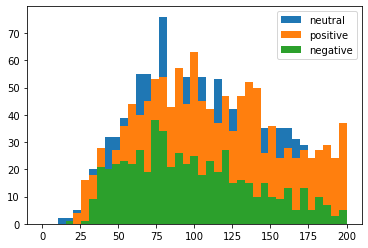

```python
bins = np.linspace(0, 200, 40)

plt.hist(news_headline_data[news_headline_data["res"]=="neutral"]["body_length"], bins, alpha=1, label="neutral")
plt.hist(news_headline_data[news_headline_data["res"]=="positive"]["body_length"], bins, alpha=1, label="positive")
plt.hist(news_headline_data[news_headline_data["res"]=="negative"]["body_length"], bins, alpha=1, label="negative")
plt.legend()
plt.show()
```

After evaluating the histogram we can deduce that the headline length is not **a distinctive new feature and can therfore be dismissed**.

# 3. Model Selection

1. **Model selection**
   1. Preparing Nested Cross Validation
   2. Support Vector machine
   3. Random Forest
   4. Model comparison and Evaluation
      1. Top Features
      2. Confusuion Matrix and F1-Score
      3. ROC Curves and AUC
      4. Selecting the better model
      5. Testing our model on some real world data

## Preelimiary Model Consideration

We chose two models to comapre on our data, which are Support Vector Machines (SVM) and RandomForest.

Support Vector Machines came to mind because we are using a Tf-Idf Vector to represent our String-Data, which have notoriously many features, especially when we are using an ngram-range to include wordpairs up to 3 words long. Kernelized SVMs are the perfect fit for that, because they can be computed effectively with a large number of features if the sample size isn't too high.

We chose Random Forests to compare. It is an Ensemble Method that can also work with a large number of features because it only uses a random subset of them to train one of its Decision-Trees.

## Defining a function for nested cross-validation

```python
from sklearn.model_selection import KFold, cross_val_score
from sklearn.metrics import roc_auc_score

def nestedCV(estimator, parameter, X, y, verbose_level=5):
    inner_cv = KFold(n_splits=4, shuffle=True, random_state=42)
    outer_cv = KFold(n_splits=4, shuffle=True, random_state=42)

    # Non_nested parameter search and scoring
    clf = GridSearchCV(estimator=estimator, param_grid=parameter, cv=inner_cv, verbose=verbose_level, n_jobs=-1, scoring='roc_auc_ovo') # -1 for paralellizing
    clf.fit(X, y)

    # Nested CV with parameter optimization
    nested_score = cross_val_score(clf, X=X, y=y, cv=outer_cv)
    return nested_score.mean(), clf
```

## Support Vector Machine Classifier (SVC) with TFIDF

```python
from sklearn.feature_selection import SelectKBest, chi2
from sklearn.svm import SVC
from sklearn.pipeline import Pipeline
from sklearn.feature_extraction.text import TfidfVectorizer

from sklearn.model_selection import GridSearchCV
```

```python
pipeline_svc = Pipeline([('tfidf_vector', TfidfVectorizer(stop_words="english", sublinear_tf=True)),
                         ('chi', SelectKBest(chi2, k=10000)),
                         ('svc_classifier', SVC(kernel='linear', max_iter=3000, probability=True))])

parameters_svc = {'tfidf_vector__ngram_range' : [(1,2), (1,3)],
                  'svc_classifier__C' : [0.5,1,1.5,2]
                 }
```

```python
svc_mean, svc_clf = nestedCV(pipeline_svc, parameters_svc, news_headline_data['text_final'], news_headline_data["res"])
```

```
Fitting 4 folds for each of 8 candidates, totalling 32 fits
```

```
[Parallel(n_jobs=-1)]: Using backend LokyBackend with 8 concurrent workers.
[Parallel(n_jobs=-1)]: Done   2 tasks      | elapsed:   15.7s
[Parallel(n_jobs=-1)]: Done  24 out of  32 | elapsed:   49.3s remaining:   16.4s
[Parallel(n_jobs=-1)]: Done  32 out of  32 | elapsed:  1.1min finished
[Parallel(n_jobs=-1)]: Using backend LokyBackend with 8 concurrent workers.
```

```
Fitting 4 folds for each of 8 candidates, totalling 32 fits
```

```
[Parallel(n_jobs=-1)]: Done   2 tasks      | elapsed:    9.4s
[Parallel(n_jobs=-1)]: Done  24 out of  32 | elapsed:   31.1s remaining:   10.3s
[Parallel(n_jobs=-1)]: Done  32 out of  32 | elapsed:   41.6s finished
```

```
Fitting 4 folds for each of 8 candidates, totalling 32 fits
```

```
[Parallel(n_jobs=-1)]: Using backend LokyBackend with 8 concurrent workers.
[Parallel(n_jobs=-1)]: Done   2 tasks      | elapsed:    8.0s
[Parallel(n_jobs=-1)]: Done  24 out of  32 | elapsed:   33.8s remaining:   11.2s
[Parallel(n_jobs=-1)]: Done  32 out of  32 | elapsed:   41.4s finished
```

```
Fitting 4 folds for each of 8 candidates, totalling 32 fits
```

```
[Parallel(n_jobs=-1)]: Using backend LokyBackend with 8 concurrent workers.
[Parallel(n_jobs=-1)]: Done   2 tasks      | elapsed:    7.9s
[Parallel(n_jobs=-1)]: Done  24 out of  32 | elapsed:   26.1s remaining:    8.6s
[Parallel(n_jobs=-1)]: Done  32 out of  32 | elapsed:   34.1s finished
```

```
Fitting 4 folds for each of 8 candidates, totalling 32 fits
```

```
[Parallel(n_jobs=-1)]: Using backend LokyBackend with 8 concurrent workers.
[Parallel(n_jobs=-1)]: Done   2 tasks      | elapsed:    8.5s
[Parallel(n_jobs=-1)]: Done  24 out of  32 | elapsed:   28.0s remaining:    9.3s
[Parallel(n_jobs=-1)]: Done  32 out of  32 | elapsed:   37.4s finished
```

```python
print(f"Mean Test Score : {svc_mean}")
final_svc_estimator = svc_clf.best_estimator_
```

```
Mean Test Score : 0.8542274079249375
```

```python
grid_search_results = pd.DataFrame(svc_clf.cv_results_).sort_values("mean_test_score", ascending=False)
column_list = ['rank_test_score',
               'mean_test_score',
               'mean_fit_time',
               'param_svc_classifier__C',
               'param_tfidf_vector__ngram_range']

grid_search_results.loc[:,column_list].head(10)
```

|  | rank_test_score | mean_test_score | mean_fit_time | param_svc_classifier__C | param_tfidf_vector__ngram_range |
| --- | --- | --- | --- | --- | --- |
| 4 | 1 | 0.855396 | 15.137958 | 1.5 | (1, 2) |
| 2 | 2 | 0.854488 | 13.865157 | 1 | (1, 2) |
| 6 | 3 | 0.853528 | 16.444477 | 2 | (1, 2) |
| 7 | 4 | 0.853116 | 14.249297 | 2 | (1, 3) |
| 5 | 5 | 0.852357 | 13.478381 | 1.5 | (1, 3) |
| 3 | 6 | 0.848500 | 12.637033 | 1 | (1, 3) |
| 0 | 7 | 0.846813 | 12.897098 | 0.5 | (1, 2) |
| 1 | 8 | 0.839144 | 11.185986 | 0.5 | (1, 3) |

```python
final_svc_estimator
```

```
Pipeline(steps=[('tfidf_vector',
                 TfidfVectorizer(ngram_range=(1, 2), stop_words='english',
                                 sublinear_tf=True)),
                ('chi',
                 SelectKBest(k=10000,
                             score_func=<function chi2 at 0x00000292E9A76D30>)),
                ('svc_classifier',
                 SVC(C=1.5, kernel='linear', max_iter=3000, probability=True))])
```

### Informations gained by the Grid-Search :

Table containing the best values for the Hyperparameters found by the GridSearch :

[output not shown]

## Random Forest with TFIDF

```python
from sklearn.ensemble import RandomForestClassifier
```

```python
pipeline_rf = Pipeline([('tfidf_vector', TfidfVectorizer(stop_words="english", sublinear_tf=True)),
                      ('chi', SelectKBest(chi2, k=10000)),
                      ('rf_classifier', RandomForestClassifier())])

parameters_rf = {'tfidf_vector__ngram_range' : [(1,2), (1,3), (2,3)],
                 'rf_classifier__n_estimators' : [50,100,150],
                 'rf_classifier__max_depth' : [100, 150, 200]
                }

rf_mean, rf_clf = nestedCV(pipeline_rf, parameters_rf, news_headline_data['text_final'], news_headline_data["res"])
```

```
Fitting 4 folds for each of 27 candidates, totalling 108 fits
```

```
[Parallel(n_jobs=-1)]: Using backend LokyBackend with 8 concurrent workers.
[Parallel(n_jobs=-1)]: Done   2 tasks      | elapsed:    3.6s
[Parallel(n_jobs=-1)]: Done  56 tasks      | elapsed:   39.8s
[Parallel(n_jobs=-1)]: Done 108 out of 108 | elapsed:  1.4min finished
```

```
Fitting 4 folds for each of 27 candidates, totalling 108 fits
```

```
[Parallel(n_jobs=-1)]: Using backend LokyBackend with 8 concurrent workers.
[Parallel(n_jobs=-1)]: Done   2 tasks      | elapsed:    2.3s
[Parallel(n_jobs=-1)]: Done  56 tasks      | elapsed:   28.0s
[Parallel(n_jobs=-1)]: Done 108 out of 108 | elapsed:  1.0min finished
```

```
Fitting 4 folds for each of 27 candidates, totalling 108 fits
```

```
[Parallel(n_jobs=-1)]: Using backend LokyBackend with 8 concurrent workers.
[Parallel(n_jobs=-1)]: Done   2 tasks      | elapsed:    2.6s
[Parallel(n_jobs=-1)]: Done  56 tasks      | elapsed:   27.0s
[Parallel(n_jobs=-1)]: Done 108 out of 108 | elapsed:   59.2s finished
```

```
Fitting 4 folds for each of 27 candidates, totalling 108 fits
```

```
[Parallel(n_jobs=-1)]: Using backend LokyBackend with 8 concurrent workers.
[Parallel(n_jobs=-1)]: Done   2 tasks      | elapsed:    2.0s
[Parallel(n_jobs=-1)]: Done  56 tasks      | elapsed:   23.6s
[Parallel(n_jobs=-1)]: Done 108 out of 108 | elapsed:   55.9s finished
```

```
Fitting 4 folds for each of 27 candidates, totalling 108 fits
```

```
[Parallel(n_jobs=-1)]: Using backend LokyBackend with 8 concurrent workers.
[Parallel(n_jobs=-1)]: Done   2 tasks      | elapsed:    2.1s
[Parallel(n_jobs=-1)]: Done  56 tasks      | elapsed:   27.0s
[Parallel(n_jobs=-1)]: Done 108 out of 108 | elapsed:   57.5s finished
```

```python
print(f"Mean Test Score : {rf_mean}")
final_rf_estimator = rf_clf.best_estimator_
```

```
Mean Test Score : 0.8309948226280124
```

```python
grid_search_results = pd.DataFrame(rf_clf.cv_results_).sort_values("mean_test_score", ascending=False)
column_list = ['rank_test_score',
               'mean_test_score',
               'mean_fit_time',
               'param_rf_classifier__max_depth',
               'param_rf_classifier__n_estimators',
               'param_tfidf_vector__ngram_range'
              ]

grid_search_results.loc[:, column_list].head(10)
```

|  | rank_test_score | mean_test_score | mean_fit_time | param_rf_classifier__max_depth | param_rf_classifier__n_estimators | param_tfidf_vector__ngram_range |
| --- | --- | --- | --- | --- | --- | --- |
| 12 | 1 | 0.829101 | 6.843013 | 150 | 100 | (1, 2) |
| 7 | 2 | 0.828262 | 9.240659 | 100 | 150 | (1, 3) |
| 6 | 3 | 0.827866 | 8.718521 | 100 | 150 | (1, 2) |
| 15 | 4 | 0.827317 | 9.372458 | 150 | 150 | (1, 2) |
| 21 | 5 | 0.827282 | 7.068556 | 200 | 100 | (1, 2) |
| 3 | 6 | 0.826545 | 5.784394 | 100 | 100 | (1, 2) |
| 16 | 7 | 0.825944 | 10.109096 | 150 | 150 | (1, 3) |
| 24 | 8 | 0.825817 | 10.035943 | 200 | 150 | (1, 2) |
| 13 | 9 | 0.824911 | 7.574671 | 150 | 100 | (1, 3) |
| 0 | 10 | 0.823552 | 3.430916 | 100 | 50 | (1, 2) |

```python
final_rf_estimator
```

```
Pipeline(steps=[('tfidf_vector',
                 TfidfVectorizer(ngram_range=(1, 2), stop_words='english',
                                 sublinear_tf=True)),
                ('chi',
                 SelectKBest(k=10000,
                             score_func=<function chi2 at 0x00000292E9A76D30>)),
                ('rf_classifier', RandomForestClassifier(max_depth=150))])
```

### Informations gained by the Grid-Search :

Table containing the best values for the Hyperparameters found by the GridSearch :

[output not shown]

## Model Comparison & Evaluation

### Top Features of Random Forest

```python
def print_top_features_rf(estimator, classifier_name, n_best):
    classifier = estimator.named_steps[classifier_name]

    importances = classifier.feature_importances_
    features = estimator.named_steps['tfidf_vector'].get_feature_names()
    cols = estimator.named_steps['chi'].get_support(indices=True)

    features_df_new = np.array(features)[cols]

    data = [[importances[i], features_df_new[i]] for i in range(len(importances))]
    data.sort(reverse=True)

    print(f"{'-'*10} Random Forest - Top Features :")
    for f in data[:n_best]:
        print(f"{f[0]} - {f[1]}")
```

```python
print_top_features_rf(final_rf_estimator, 'rf_classifier', 20)
```

```
---------- Random Forest - Top Features :
0.015000260135138492 - profit
0.013685168632972488 - decreased
0.012512605259629411 - rose
0.01049075160900999 - year
0.008583230991806927 - increase
0.00855237651411686 - sale
0.008312906972474273 - compared
0.008292411626692855 - fell
0.0082108097332645 - said
0.008012846247541701 - period
0.007938711014058865 - operating
0.007743629010756802 - signed
0.0076962236243306725 - increased
0.007436783239166068 - net
0.006688882688067656 - loss
0.006576673682303778 - operating profit
0.006083460161006159 - awarded
0.005571011469863069 - quarter
0.005544964153584516 - finnish
0.00492370531236976 - share
```

### Confusion Matrix and F1-Score

```python
from sklearn.metrics import plot_confusion_matrix
from sklearn.model_selection import train_test_split
from sklearn.metrics import f1_score

def confusion_matrix(estimator, ax, test_size=.25, classifier_title=''):

    X_train, X_test, y_train, y_test = train_test_split(news_headline_data['text_final'], news_headline_data['res'], test_size=test_size, random_state=42)

    estimator.fit(X_train, y_train)

    class_names = ['negative', 'neutral', 'positive']

    titles_options = [(f"Confusion matrix, without normalization [{classifier_title}]", None, ax[0]),
                      (f"Normalized confusion matrix [{classifier_title}]", 'true', ax[1])]
    for title, normalize, axis in titles_options:
        disp = plot_confusion_matrix(estimator, X_test, y_test,
                                     display_labels=class_names,
                                     ax=axis,
                                     cmap=plt.cm.Blues,
                                     normalize=normalize)
        disp.ax_.set_title(title)

    y_pred = estimator.predict(X_test)
    print(f"F1-score [{classifier_title}]: {f1_score(y_test, y_pred, average='micro')}")

    return disp

def plot_confusion_matrices(svc_estimator, rf_estimator):
    fig, ax = plt.subplots(2,2, figsize=(15,10))
    confusion_matrix(svc_estimator, ax[:,0], classifier_title='SVC')
    confusion_matrix(rf_estimator, ax[:,1], classifier_title='Random Forest')
    fig.tight_layout()
    plt.show()
```

```
F1-score [SVC]: 0.7019230769230769
F1-score [Random Forest]: 0.6526442307692307
```

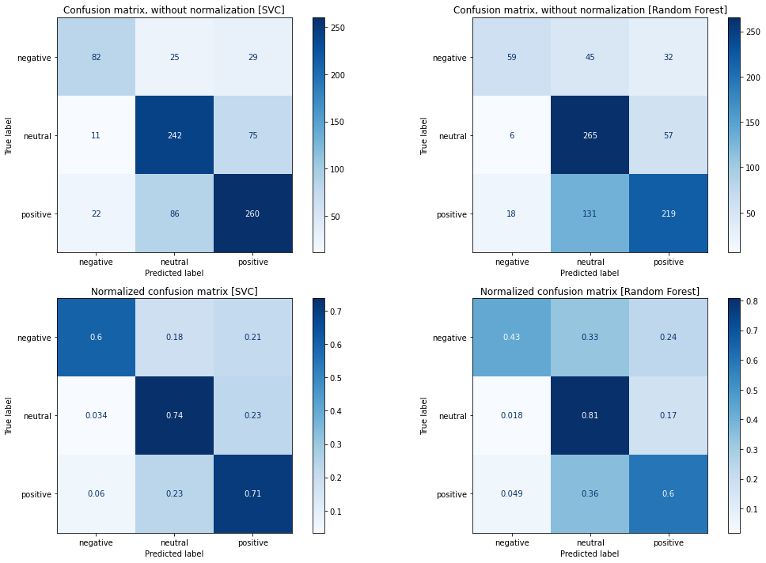

```python
from copy import deepcopy

test_svc = deepcopy(final_svc_estimator)
test_rf = deepcopy(final_rf_estimator)

plot_confusion_matrices(test_svc, test_rf)
```

## ROC Curve and AUC

```python
from itertools import cycle

from sklearn import svm, datasets
from sklearn.metrics import roc_curve, auc
from sklearn.preprocessing import label_binarize
from sklearn.multiclass import OneVsRestClassifier
from numpy import interp
from sklearn.metrics import roc_auc_score

def roc_curves_multi_class(estimator, axis, plot_micro=True, plot_macro=False, title='AUC Curves', test_size=.25):

    X = news_headline_data['text_final']
    y = news_headline_data['res']
    y = label_binarize(y, classes=['negative', 'neutral', 'positive'])

    n_classes = 3

    X_train, X_test, y_train, y_test = train_test_split(X, y, test_size=test_size, random_state=0)

    classifier = OneVsRestClassifier(estimator)

    y_score = classifier.fit(X_train, y_train).predict_proba(X_test)

    # Compute ROC curve and ROC area for each class
    fpr = dict()
    tpr = dict()
    roc_auc = dict()
    for i in range(n_classes):
        fpr[i], tpr[i], _ = roc_curve(y_test[:, i], y_score[:, i])
        roc_auc[i] = auc(fpr[i], tpr[i])

    # Compute micro-average ROC curve and ROC area
    fpr["micro"], tpr["micro"], _ = roc_curve(y_test.ravel(), y_score.ravel())
    roc_auc["micro"] = auc(fpr["micro"], tpr["micro"])

    # First aggregate all false positive rates
    all_fpr = np.unique(np.concatenate([fpr[i] for i in range(n_classes)]))

    # Then interpolate all ROC curves at this points
    mean_tpr = np.zeros_like(all_fpr)
    for i in range(n_classes):
        mean_tpr += interp(all_fpr, fpr[i], tpr[i])

    # Finally average it and compute AUC
    mean_tpr /= n_classes

    fpr["macro"] = all_fpr
    tpr["macro"] = mean_tpr
    roc_auc["macro"] = auc(fpr["macro"], tpr["macro"])

    lw=2

    if plot_micro:
        # Plot Micro-Average ROC Curve
        axis.plot(fpr["micro"], tpr["micro"],
                 label='micro-average ROC curve (area = {0:0.2f})'
                       ''.format(roc_auc["micro"]),
                 color='deeppink', linestyle=':', linewidth=4)

    if plot_macro:
        # Plot Macro-Average ROC Curve
        axis.plot(fpr["macro"], tpr["macro"],
                 label='macro-average ROC curve (area = {0:0.2f})'
                       ''.format(roc_auc["macro"]),
                 color='navy', linestyle=':', linewidth=4)

    axis.plot([0, 1], [0, 1], 'k--', lw=lw)
    axis.set_xlim([0.0, 1.0])
    axis.set_ylim([0.0, 1.05])
    axis.set_xlabel('False Positive Rate')
    axis.set_ylabel('True Positive Rate')
    axis.set_title(title)
    axis.legend(loc="lower right")

    return [fpr['micro'], tpr['micro'], roc_auc['micro']], [fpr['macro'], tpr['macro'], roc_auc['macro']]

def plot_multi_roc(roc_arr, titles, axis, plot_title='ROC Curve Comparison'):
    lw = 2
    # roc_arr is a list of fprs, tprs and auc_score for each roc curve
    colors = ['red', 'green']
    for i in range(len(roc_arr)):
        axis.plot(roc_arr[i][0], roc_arr[i][1],
                     label=f'[{titles[i]}] micro-average ROC curve (area = {0:0.2f})'
                           ''.format(roc_arr[i][2]),
                     color=colors[i%len(colors)], linestyle=':', linewidth=4)

    axis.plot([0, 1], [0, 1], 'k--', lw=lw)
    axis.set_xlim([0.0, 1.0])
    axis.set_ylim([0.0, 1.05])
    axis.set_xlabel('False Positive Rate')
    axis.set_ylabel('True Positive Rate')
    axis.set_title(plot_title)
    axis.legend(loc="lower right")
```

[figure not shown]

```python
from matplotlib import gridspec

fig = plt.figure(tight_layout=True, figsize=(15,10))
gs = gridspec.GridSpec(2, 2)
ax0 = fig.add_subplot(gs[0,0])
ax1 = fig.add_subplot(gs[0,1])
ax2 = fig.add_subplot(gs[1,:])

#fig, ax = plt.subplots(2,2, figsize=(15,10))
svc_micro, svc_macro = roc_curves_multi_class(final_svc_estimator, ax0, plot_macro=True, title='ROC Curves of the SVC')
rf_micro, rf_macro = roc_curves_multi_class(final_rf_estimator, ax1, plot_macro=True, title='ROC Curves of the Random Forest')
plot_multi_roc([svc_micro, rf_micro], ['SVC', 'Random Forest'], ax2)
plt.show()
```

## Selecting the better Model

[output not shown]

## Testing the final Model on some real world data

```python
data = [["A Tesla Bull Makes a Bold Call: The Stock Can Triple in Price", "positive"],
        ["Why the Worst Could Be Over for Visa and Mastercard, and How PayPal Could Keep Rising", "positive"],
        ["Apple Will Release Its 5G iPhones Next Week.", "neutral"],
        ["Energy Stocks fell Almost 50% This Year. Time to Buy.", "negative"],
        ["As Trump says he’s abandoned stimulus talks, renters and landlords face a financial cliff", "negative"]]
```

```python
def preprocessing(string):
    step_0 = remove_numbers(string.lower())
    step_1 = remove_punctuation(step_0)
    step_2 = nltk.word_tokenize(step_1)
    step_3 = remove_stopwords(step_2)
    step_4 = lemmatizing(step_3)
    return " ".join(step_4)
```

```python
def test_model(estimator, arr):
    labels = [elem[1] for elem in arr]
    headlines = [preprocessing(elem[0]) for elem in arr]
    y_pred = estimator.predict(headlines)
    for i in range(len(y_pred)):
        print(f"[{labels[i]}] - predited calss : [{y_pred[i]}] -  {headlines[i]}")
```

```python
test_model(final_svc_estimator, data)
```

```
[positive] - predited calss : [neutral] -  tesla bull make bold call stock triple price
[positive] - predited calss : [positive] -  worst could visa mastercard paypal could keep rising
[neutral] - predited calss : [neutral] -  apple release g iphones next week
[negative] - predited calss : [negative] -  energy stock fell almost year time buy
[negative] - predited calss : [neutral] -  trump say ’ abandoned stimulus talk renter landlord face financial cliff
```

# 4. Conclusion

1. **Conclusion and outlook**
   1. Outlookon possible future model imporvements

## Outlookon possible future model imporvements

- Klassenbias entfernen:
  - SMOTE (Synthetic Minority Oversampling Technique)
  - Händisch auffüllen/Webscrapen
- Strategie um numerische Werte zu interpretieren
- Verbindung mehrerer Modelle und Ensemble Methoden (v.a. für SVC) anwenden:
  - Boosting, um negative Klassen besser zu klassifizieren
- Transformermodelle (NN) anwenden
- Modulares Projekt zur technischen Analyse von Wirtschaftskonjunktur und Aktienverläufen
- Sentiment Analysis (historisch) mit Kursentwicklung verbinden
- Korrelation von Sentiment aus anderen Bereichen (ggf. „Normalen“ Nachrichten) mit Finanznachrichten und Auswirkungen untersuchen
- Zeitreihenanalysen/-vorhersagen und mit Sentimentanalysis verbinden

# Quellen :

- Sinha, A.: (Datensatz für Projekt) Sentiment Analysis for Financial News (2020), https://www.kaggle.com/ankurzing/sentiment-analysis-for-financial-news (Aufgerufen: 10.10.2020)
- Gunjit, B.: A guide to Text Classification(NLP) using SVM and Naive Bayes with Python (2018), Web: https://medium.com/@bedigunjit/simple-guide-to-text-classification-nlp-using-svm-and-naive- bayes-with-python-421db3a72d34 (Aufgerufen: 9.9.2020)
- Precision-Recall, Web: https://scikit-learn.org/stable/auto_examples/model_selection/plot_precision_recall.html (Aufgerufen: 9.9.2020)
- Goonewardana, H.: Evaluating Multi-Class Classifiers (2019), https://medium.com/apprentice-journal/evaluating-multi-class-classifiers-12b2946e755b (Aufgerufen: 9.9.2020)
- Hilfestellungen zur Multi-Class ROC Kurve mit Scikit-Learn, Web: https://scikit-learn.org/stable/auto_examples/model_selection/plot_roc.html (Aufgerufen: 01.10.2020)
- Vaughan, D.: Multiclass Averaging (2020), Web: https://cran.r-project.org/web/packages/yardstick/vignettes/multiclass.html (Aufgerufen: 01.10.2020)
- How to increase the speed for SVM classifier using Sk-learn, https://stackoverflow.com/questions/34939683/how-to-increase-the-speed-for-svm-classifier-using-sk-learn (Aufgerufen: 9.9.2020)
- SVC classifier taking too much time for training, https://stackoverflow.com/questions/53940258/svc-classifier-taking-too-much-time-for-training (Aufgerufen: 9.9.2020)
- VanderPlas, Jake: Python Data Science Handbook (2016)